### OPTIONAL: Did you create any models with your dataset?

Discuss the and limitations of your model.

#### STRENGTH-

Optimal for Univariate forecast of a Time series data Uses lags(previous values) to help possible predict future values 80% confidence limits shaded in darker blue, and 95% in lighter blue.

#### WEAKNESS-

The forecast broadens and becomes less relaible as time increase

# Final Plots and Summary

### Plot One

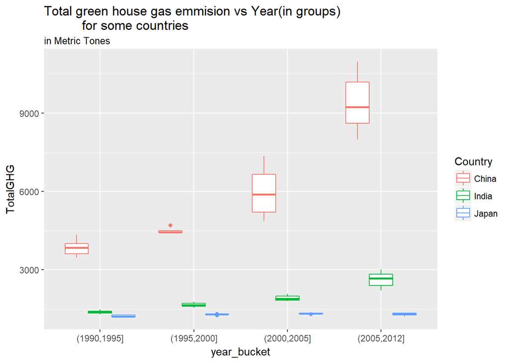

### Plot Two

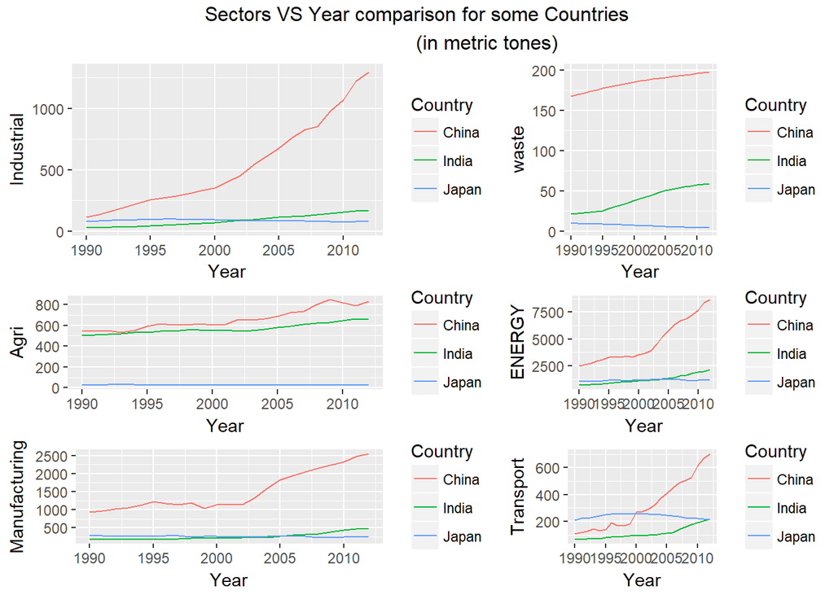

[output not shown]

### Description Two

The plot dipicts the trend followed by some of the countries over the years in diffrent fields such as Transport , Manufacturing etc .China is mostly at the to in Emmision . The trend is in the Increasing direction mostly but Japan is showing a decreasing trend in variables such as Transport emmision , Emmision due to waste which is very rare given this dataset.

### Plot Three

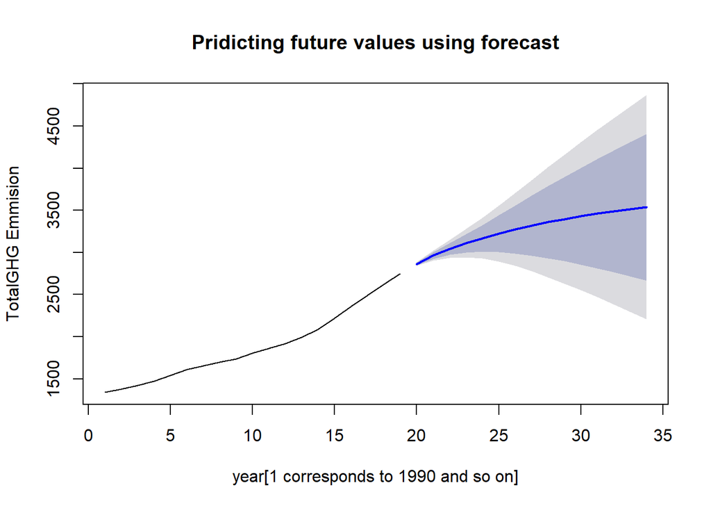

### Description Three

Forecast of timeseries data of India pridicting next 15 values for total ghg emissions. 80% confidence limits shaded in darker blue, and 95% in lighter blue. Longer term forecasts will usually have more uncertainty, as the model gives further future values it will become more and more uncertain this could be seen as the spread increases along the xaxis(time)

# Reflection

> Green House Gases are the major factors in promoting Global warming and is a global threat .Mostly Univariate Analysis was only useful for finding the nature and distribution of data not much Could be drawn out from it . Bivariate analysis helped in identifieng the anomalities / diffrent patterns in the Data This was very Useful as the data was highly corelated and it would mostly be a increasing linear Trend. Finnaly The Multivariate Analysis brought about some meaningful analytics and some infrences Could be drawn from it. Time series Data was bit diffrent Than a Normal Data and hence modeling it was a chalange at first but with the right model it was very effect to Analayze and produce prictions for this Data The huge diffrences in emmision of countries like Japan And China Were Note worthy Though they also have diffrence in Population and Land-Mass But Japan had a significantly more GDP Percapita Than China.  
> The Analysis of of Emmisions with Various Economic and social parametres could be done to produce more insights .